# Organized Crime

CRIM 100

## Today’s Topics

- Defining organized crime
- Modern OC constructs
- OC in Canada

# Defining OC

## What is OC?

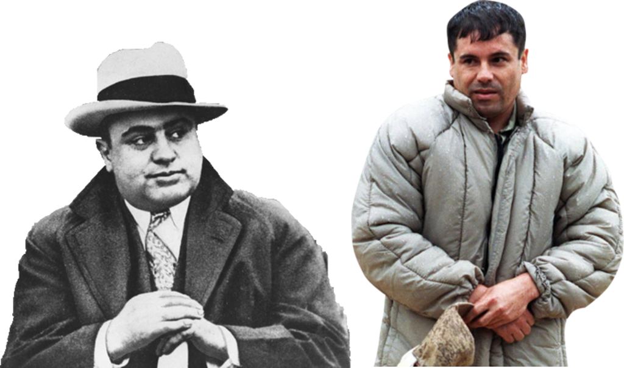

## Evolution of OC Definition

- Thrasher (1927)
- Traditional organized crime vs non-traditional (emerging) organized crime

## Static Definitions

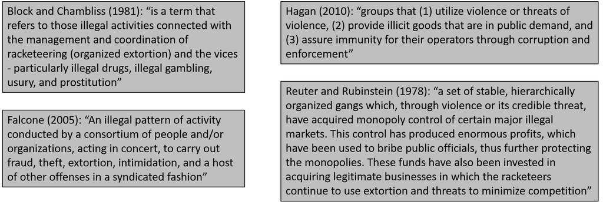

## Abadinsky’s (2010) Definition

- Organized crime:
  - Has no political goals
  - Is hierarchical
  - Has a limited or exclusive membership
  - Constitutes a unique subculture
  - Perpetuates itself
  - Exhibits a willingness to use illegal violence
  - Is monopolistic
  - Is governed by explicit rules and regulations

## Lupsha’s (1996) Stages of OC

- Predatory
- Parasitic
- Symbiotic

## Lupsha’s Predatory Stage

- Spatially constrained
- Defensive crimes
- Violence: territory, rivals & local monopoly of illicit use of force
- Offences seek immediate rewards
- Once dominance over territory is established: -Extortion of local businesses
  - More sophisticated criminals and politicians start to use them
- Most manageable phase

## Lupsha’s Parasitic Stage

- Maturation: age, criminal skills, leadership & role specialization
- Corrupt interaction with politicians
- Window of opportunity for legitimization (full parasitic interaction)
- Supply of illegal goods & services keeps things running smoothly
- The police designate group as organized crime
- Group is featured in TV & movies
- Group accumulates enough money to:
  - Finance and support political campaigns
  - Secure protection from corrupt politicians
  - Penetrate the legitimate business world

## Lupsha’s Symbiotic Stage

- Parasitic relationship becomes mutual
- Group holds monopoly over certain legal and illegal businesses
- Group becomes a key player in political dynamic

## Hells Angels

[video not shown]

# Modern OC constructs

## Why the cartels are winning

[video not shown]

## Complexity of OC Activities

- Intergroup collaboration
- Market-based approach to OC

## Morselli (2009)

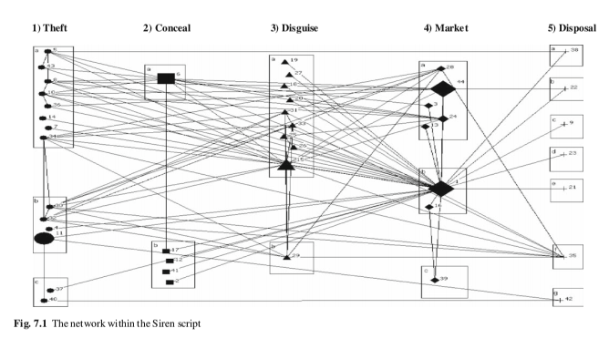

## Malm et al. (2011)

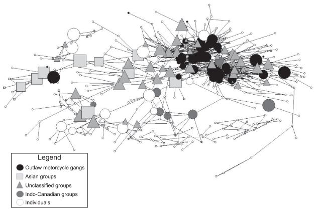

## Ethnicity Still Plays a Role

- Minimize uncertainty and risk
- Secrecy - Language and cultural barriers for law enforcement
- Loyalty - Access to relatives and friends

## Emergence of OC Crime Opportunities

- Produced by shifts and trends
  - Economic
  - Social
  - Political
  - Regulations & enforcement

## Push & Pull Factors for OC

- Push
  - Increased law enforcement
  - Increased competition from criminal groups (selection effect)
- Pull
  - Mass demand
  - Access to supply
  - Lax law enforcement
  - High impunity/corruption
  - Proximity to trafficking routes
  - Porous borders
  - Presence of brokers and facilitator

# OC in Canada

## Factors Associated with OC in Canada

- Transit country (stolen cars, jewellery, drugs & large-scale scams)
  - Colombian, Asian & Russian groups
- Cities’ physical & geographical features
  - Ports & points of entry
  - Population size & heterogeneity
  - Banking & financial institutions
- Vancouver vs Montreal

# Content review

## Key Concepts

- Traditional organized crime
- Non-traditional (emerging) organized crime
- Lupsha’s (1996) stages of OC (predatory, parasitic & symbiotic)
- Market-place approach to OC
- Emergence of OC crime opportunities
- Push & pull factors for OC
- Factors associated with OC in Canada